# Series temporales

Javier Aos

# Parte 1: Series temporales

## Presentación de la serie a analizar

En esta ocasión vamos a analizar una serie temporal del producto interior bruto (PIB) mundial obtenida de “U.S. Energy Information Administration Data”. Contamos con datos mensuales desde el año 2000 hasta el 2021 incluidos.

```r
df <- read.csv(
  'G:/My Drive/1.3 Master/Modules/08_Data_mining/TareaII/EIA-STEO_RGDPQ_WORLD_M.csv',
  sep = ",")
df <- df[order(as.numeric(rownames(df)), decreasing = TRUE),,drop=FALSE]
gdp_ts <- ts(df$Value, start=c(2000,1), frequency = 12)
```

## Representación gráfica y descomposición estacional

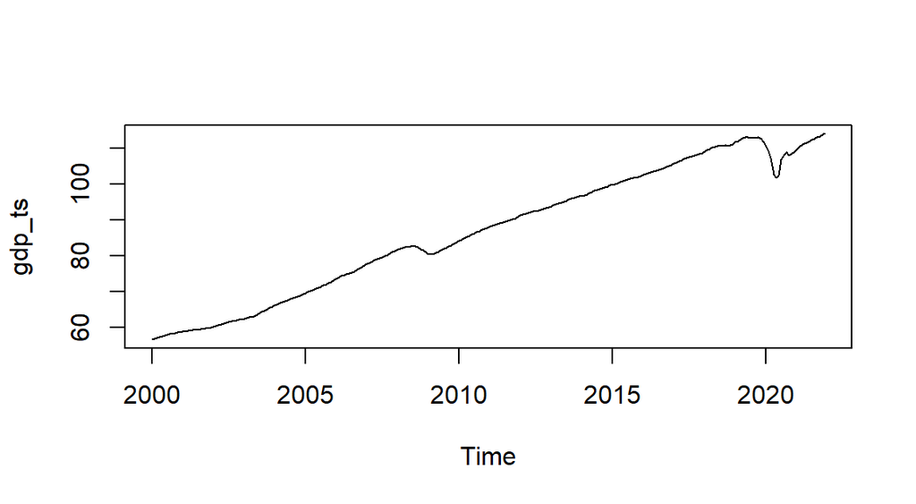

```r
plot.ts(gdp_ts)
```

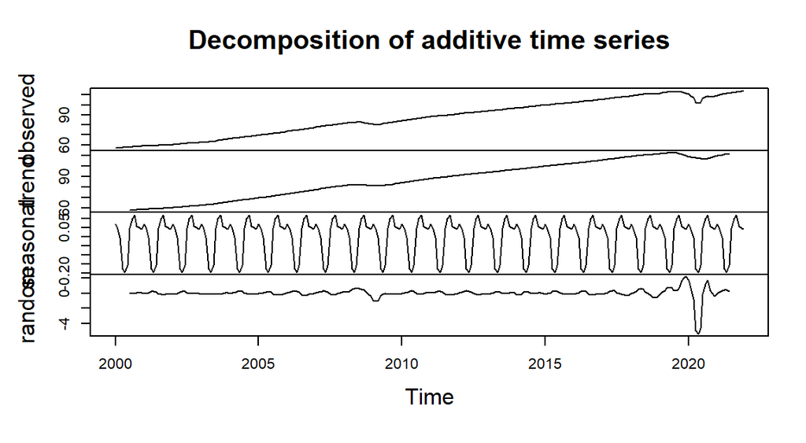

```r
gdp_desc <- decompose(gdp_ts, type = 'additive')
plot(gdp_desc)
```

Podemos ver que la serie presenta una tendencia ascendente lineal con ciertas recesiones en algunos periodos. A priori no hay comportamiento estacional lo cual va a dificultar la predicción.

## Contraste de normalidad de los residuos

```r
ks.test(gdp_desc$random,'pnorm')
```

```
##
##  Asymptotic one-sample Kolmogorov-Smirnov test
##
## data:  gdp_desc$random
## D = 0.33464, p-value < 2.2e-16
## alternative hypothesis: two-sided
```

```r
shapiro.test(gdp_desc$random)
```

```
##
##  Shapiro-Wilk normality test
##
## data:  gdp_desc$random
## W = 0.49804, p-value < 2.2e-16
```

Vemos que los residuos no pasan los tests de normalidad.

## Tratamiento de la serie

### Eliminar la heterocedasticidad. Estabilización de la varianza.

```r
gdplog <- log(gdp_ts)
```

#### Eliminar tendencia

```r
# Eliminar tendencia
gdp.diff_1<-diff(gdplog)
```

### Comprobación y corrección de la estacionalidad (Correlogramas)

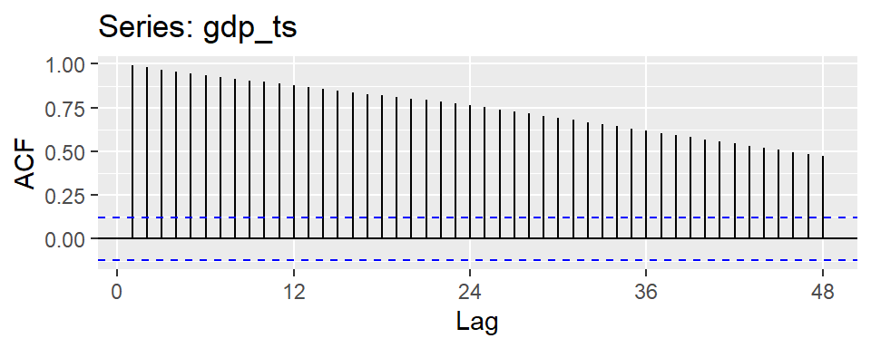

```r
library(forecast)
#Calculamos  las autocorrelaciones simples hasta el retardo 48
ggAcf(gdp_ts, lag=48) # Decrecimineto lento--> No estacionaria-->diferenciar
```

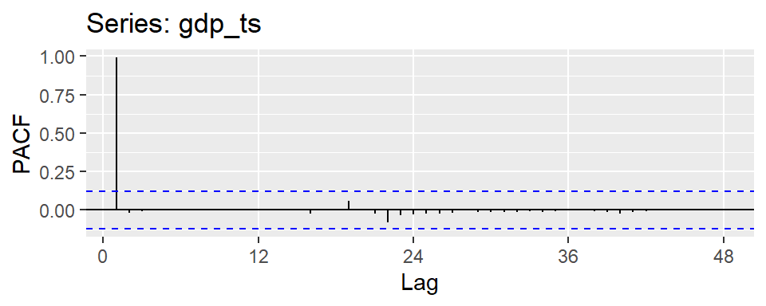

```r
#Calculamos  las autocorrelaciones parciales hasta el retardo 48
ggPacf(gdp_ts, lag=48)
```

Vemos que la serie no es estacionaria, por lo tanto, la diferenciamos.

```r
gdp.diff_1_12<-diff(gdp.diff_1, lag = 12)
```

```r
## Contraste de normalidad de los residuos
ks.test(gdp.diff_1_12,'pnorm')
```

```
##
##  Asymptotic one-sample Kolmogorov-Smirnov test
##
## data:  gdp.diff_1_12
## D = 0.48387, p-value < 2.2e-16
## alternative hypothesis: two-sided
```

```r
shapiro.test(gdp.diff_1_12)
```

```
##
##  Shapiro-Wilk normality test
##
## data:  gdp.diff_1_12
## W = 0.57604, p-value < 2.2e-16
```

Sigue sin pasar los tests de normalidad.

## Ventanas de ajuste y evaluación

```r
gdp_tr<-window(x = gdp_ts, end = c(2020,12))
gdp_tst<-window(x = gdp_ts, start = c(2021,1))
```

## Modelos de suavizado exponencial

### Suavizado exponencial simple con predicción a un año

```r
gdp_s1=ses(gdp_tr, h=12)
```

### Suavizado Exponencial doble de Holt

```r
gdp_sh <- holt(gdp_tr, h=12)
```

### Ajuste de modelo

```r
gdp_hw_add <- hw(gdp_tr, h=12,level = c(80, 95))
gdp_hw_mul <- hw(gdp_tr, h=12, seasonal="multiplicative",level = c(80, 95))
```

### Predicciones utilizando ETS

```r
ETS_pred<-forecast(gdp_tr,h=12)
```

## Modelos ARIMA

### Ajuste con la función auto.arima

```r
fitgdp <- auto.arima(gdp_tr,seasonal=TRUE)
pred <- forecast(fitgdp, h=12)
```

### Ajuste manual de ARIMA

```r
fitgdp_manual <- gdp_tr %>%  Arima(order=c(1,1,1), seasonal=c(0,0,1))
pred_manual <- forecast(fitgdp_manual, h=12)
```

## Se prueba la precisión de las distintas predicciones de los modelos

```r
accuracy(gdp_s1,gdp_tst)
```

```
##                     ME      RMSE       MAE       MPE      MAPE      MASE
## Training set 0.2073179 0.5382369 0.3256878 0.2581361 0.3749126 0.1049427
## Test set     3.2651359 3.5098134 3.2651359 2.9010985 2.9010985 1.0520881
##                   ACF1 Theil's U
## Training set 0.5361040        NA
## Test set     0.7234365  9.068741
```

```r
accuracy(gdp_sh,gdp_tst)
```

```
##                        ME      RMSE       MAE         MPE      MAPE       MASE
## Training set 0.0008501899 0.4708800 0.1373190 0.002020022 0.1412512 0.04424675
## Test set     0.4902944407 0.5342683 0.4902944 0.439481903 0.4394819 0.15798208
##                     ACF1 Theil's U
## Training set 0.009804084        NA
## Test set     0.809612483  1.336649
```

```r
accuracy(gdp_hw_add,gdp_tst)
```

```
##                       ME     RMSE       MAE         MPE      MAPE       MASE
## Training set -0.03801679 0.501254 0.2144489 -0.04924557 0.2410272 0.06909946
## Test set      2.88699581 3.080212 2.8869958  2.56583099 2.5658310 0.93024428
##                   ACF1 Theil's U
## Training set 0.5181978        NA
## Test set     0.6941635  7.951705
```

```r
accuracy(gdp_hw_mul,gdp_tst)
```

```
##                        ME      RMSE       MAE          MPE      MAPE      MASE
## Training set -0.004536171 0.7126354 0.3800441 -0.005421379 0.4570778 0.1224573
## Test set      2.141824205 2.3047906 2.1418242  1.909111116 1.9091111 0.6901360
##                   ACF1 Theil's U
## Training set 0.4678362        NA
## Test set     0.4459574  5.956788
```

```r
accuracy(ETS_pred,gdp_tst)
```

```
##                      ME      RMSE       MAE        MPE      MAPE       MASE
## Training set 0.04429215 0.4373885 0.1478183 0.05605733 0.1567605 0.04762985
## Test set     1.88499621 2.0696707 1.8849962 1.67378570 1.6737857 0.60738119
##                     ACF1 Theil's U
## Training set -0.04945731        NA
## Test set      0.72762515  5.340513
```

```r
accuracy(pred,gdp_tst)
```

```
##                         ME      RMSE       MAE          MPE      MAPE
## Training set  0.0004856905 0.3644419 0.1490017  0.001399768 0.1591885
## Test set     -4.7615218616 5.4652867 4.7615219 -4.240614347 4.2406143
##                    MASE      ACF1 Theil's U
## Training set 0.04801114 0.2073478        NA
## Test set     1.53425178 0.5869337  14.26192
```

```r
accuracy(pred_manual,gdp_tst)
```

```
##                      ME      RMSE      MAE       MPE      MAPE       MASE
## Training set 0.09405538 0.4269676 0.184619 0.1170861 0.2043887 0.05948772
## Test set     1.96530901 2.3793267 1.965309 1.7414905 1.7414905 0.63325948
##                     ACF1 Theil's U
## Training set -0.04658652        NA
## Test set      0.77654148   6.13155
```

Vemos que la predicción que más se ajusta a los datos test es la del método Holt’s (gdp_sh). Por lo tanto lo seleccionamos y ajustamos a los datos totales.

## Representación de la predicción del mejor modelo (Doble Holt)

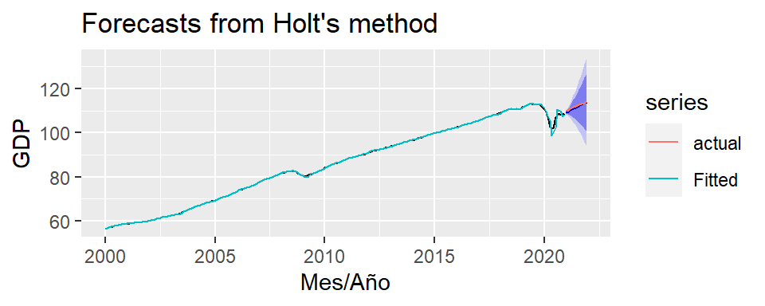

```r
#Representamos los valores observados y los suavizados con la predicción
autoplot(gdp_sh) +
  autolayer(fitted(gdp_sh), series="Fitted") +autolayer(gdp_tst, series="actual") +
  ylab("GDP") + xlab("Mes/Año")
```

## Ajuste del modelo final a los datos completos y predicción

```r
###  Suavizado Exponencial doble de Holt
gdp_sh_total <- holt(gdp_ts, h=12)
# Inspección del objeto creado y Distribución de residuos
print(gdp_sh_total)
```

```
##          Point Forecast    Lo 80    Hi 80    Lo 95    Hi 95
## Jan 2022       114.4964 113.8996 115.0932 113.5836 115.4092
## Feb 2022       114.9209 113.6805 116.1614 113.0238 116.8180
## Mar 2022       115.3454 113.3370 117.3539 112.2738 118.4171
## Apr 2022       115.7699 112.8845 118.6554 111.3570 120.1828
## May 2022       116.1945 112.3345 120.0544 110.2912 122.0977
## Jun 2022       116.6190 111.6958 121.5422 109.0896 124.1484
## Jul 2022       117.0435 110.9750 123.1120 107.7625 126.3245
## Aug 2022       117.4680 110.1776 124.7585 106.3182 128.6178
## Sep 2022       117.8925 109.3081 126.4770 104.7637 131.0213
## Oct 2022       118.3170 108.3702 128.2638 103.1047 133.5293
## Nov 2022       118.7416 107.3674 130.1157 101.3463 136.1369
## Dec 2022       119.1661 106.3023 132.0299  99.4926 138.8395
```

```r
gdp_sh_total$model
```

```
## Holt's method
##
## Call:
##  holt(y = gdp_ts, h = 12)
##
##   Smoothing parameters:
##     alpha = 0.9975
##     beta  = 0.8246
##
##   Initial states:
##     l = 56.2792
##     b = 0.2389
##
##   sigma:  0.4657
##
##      AIC     AICc      BIC
## 1074.518 1074.751 1092.398
```

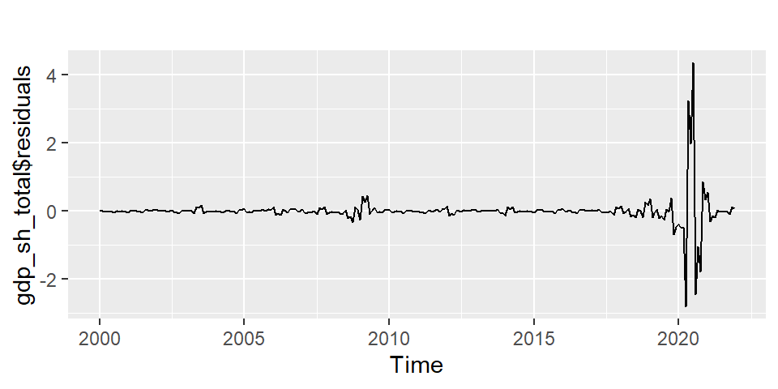

```r
autoplot(gdp_sh_total$residuals)
```

## Representación gráfica de la predicción

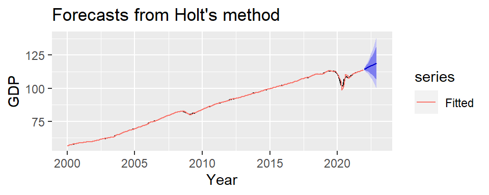

```r
autoplot(gdp_sh_total)+ autolayer(fitted(gdp_sh_total), series="Fitted") +
  ylab("GDP") + xlab("Year")
```

## Test de Ljung-Box

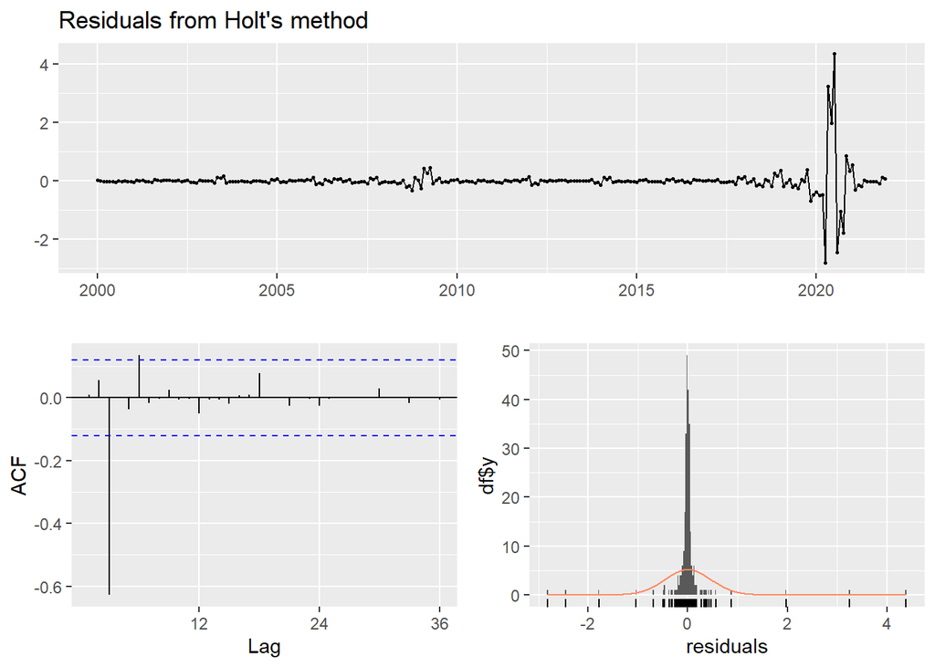

```
##
##  Ljung-Box test
##
## data:  Residuals from Holt's method
## Q* = 115.49, df = 20, p-value = 1.887e-15
##
## Model df: 4.   Total lags used: 24
```

```r
forecast::checkresiduals(gdp_sh_total)
```

A pesar de ser el mejor modelo no pasa el test de Ljung-Box de residuos incorrelados.

## Conclusiones

Parece que ninguno de los modelos es los bastante adecuado como para poder sacar conclusiones y predicciones acertadas. Además, como hemos visto, el mejor modelo no pasa el test de Ljung-Box de residuos incorrelados, por lo que las predicciónes que hagamos no serán precisas. Aún así, con el objetivo de sacar una conclusión final de esta práctica, siguiendo la tendencia y la predicción del suavizado exponencial doble Holt, podemos concluir que el PIB mundial seguirá su tendencia creciente en 2022.